# Perks of Being a Wallflower

Author: Stephen Chbosky

**“There’s nothing like deep breaths after laughing that hard. Nothing in the world like a sore stomach for the right reasons.”**

― Stephen Chbosky, The Perks Of Being A Wallflower

[figure not shown]

## Summary

Charlie is a freshman.

And while he’s not the biggest geek in the school, he is by no means popular. Shy, introspective, intelligent beyond his years yet socially awkward, he is a wallflower, caught between trying to live his life and trying to run from it.

Charlie is attempting to navigate his way through uncharted territory: the world of first dates and mix tapes, family dramas and new friends; the world of sex, drugs, and The Rocky Horror Picture Show, when all one requires is that perfect song on that perfect drive to feel infinite. But he can’t stay on the sideline forever. Standing on the fringes of life offers a unique perspective. But there comes a time to see what it looks like from the dance floor.

The Perks of Being a Wallflower is a deeply affecting coming-of-age story that will spirit you back to those wild and poignant roller-coaster days known as growing up.

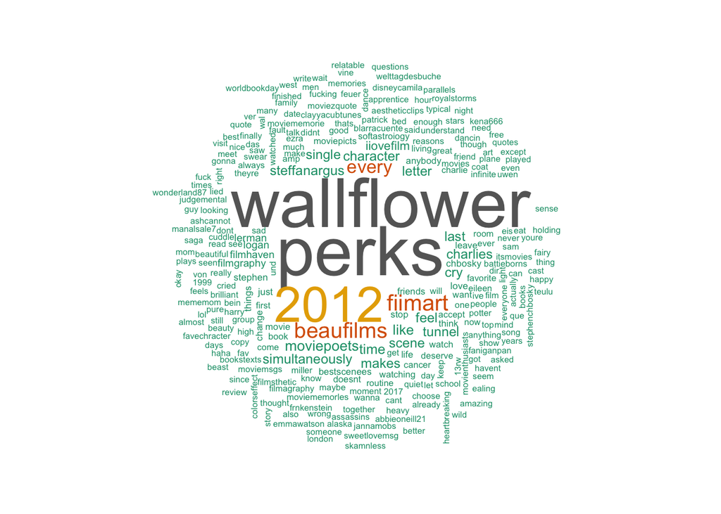

## Recent Tweets

```
## [1] "CelestialCarra: RT @steffanargus: why do i simultaneously feel like every character in perks of being a wallflower."
## [1] "trashactually: RT @steffanargus: why do i simultaneously feel like every character in perks of being a wallflower."
## [1] "Im_sarahbeth: RT @steffanargus: why do i simultaneously feel like every character in perks of being a wallflower."
## [1] "anna_grace25: RT @moviepoets: The Perks of Being A Wallflower (2012) https://t.co/xPW37O1oz7"
## [1] "zayanosis: RT @steffanargus: why do i simultaneously feel like every character in perks of being a wallflower."
## [1] "LZinselmeier: RT @moviepoets: The Perks of Being A Wallflower (2012) https://t.co/xPW37O1oz7"
## [1] "blankpepper: RT @beaufilms: The Perks of Being A Wallflower (2012) https://t.co/hlZ1eRIQwV"
## [1] "blankpepper: RT @beaufilms: The Perks of Being a Wallflower (2012) https://t.co/tGi24YroiH"
## [1] "alexrxe: RT @steffanargus: why do i simultaneously feel like every character in perks of being a wallflower."
## [1] "naddykalen: RT @moviepoets: The Perks of Being A Wallflower (2012) https://t.co/xPW37O1oz7"
## [1] "sonicyouth___: RT @steffanargus: why do i simultaneously feel like every character in perks of being a wallflower."
## [1] "wdbthejudge: RT @steffanargus: why do i simultaneously feel like every character in perks of being a wallflower."
## [1] "xweirdoxx: RT @AestheticClips: The Perks of Being a Wallflower • 2012 https://t.co/DP5jpCKEsW"
## [1] "rebeccaa_hi: RT @steffanargus: why do i simultaneously feel like every character in perks of being a wallflower."
## [1] "miauybieber: RT @moviepoets: The Perks of Being A Wallflower (2012) https://t.co/xPW37O1oz7"
## [1] "itskatiek: RT @moviepoets: The Perks of Being A Wallflower (2012) https://t.co/xPW37O1oz7"
## [1] "95mje: RT @steffanargus: why do i simultaneously feel like every character in perks of being a wallflower."
## [1] "isabeieks: RT @fiImart: The Perks of Being a Wallflower (2012) https://t.co/Cc3R82PoP3"
## [1] "abi_cash: RT @moviepoets: The Perks of Being A Wallflower (2012) https://t.co/xPW37O1oz7"
## [1] "_angehh: RT @steffanargus: why do i simultaneously feel like every character in perks of being a wallflower."
```

[output not shown]

[figure not shown]

```r
#library(plotly)
#packageVersion('plotly')

#p <- plot_ly(
#  plotly::tweets.df, r = ~latitude, t = ~longitude, color = ~nms, alpha = 0.5, type = "scatter"
#)
#layout(p, title = "Mic Patterns", orientation = -90)
```

## Key Themes

- bookstomovies
- triggerwarning
- firstlove
- comingofage

## Extras

- Also a major motion picture starring Logan Lerman and Emma Watson
- A #1 New York Times best seller for more than a year
- An American Library Association Best Book for Young Adults (2000)
- Best Book for Reluctant Readers (2000)
- summary from Goodreads
- extras from Barnes & Noble